# pstat 131 hw 6

1. Read in the data and set things up as in Homework 5:

```r
pokemon<- read.csv('/Users/ankitapattnaik/Downloads/homework-5/data/Pokemon.csv')
```

Use clean_names() Filter out the rarer Pokémon types Convert type_1 and legendary to factors Do an initial split of the data; you can choose the percentage for splitting. Stratify on the outcome variable.

Fold the training set using v-fold cross-validation, with v = 5. Stratify on the outcome variable.

Set up a recipe to predict type_1 with legendary, generation, sp_atk, attack, speed, defense, hp, and sp_def:

Dummy-code legendary and generation; Center and scale all predictors.

```r
pokemon <-clean_names(pokemon)
set.seed(0714)

pokemon <- pokemon %>%
  filter(type_1 == "Bug" | type_1 == "Fire" | type_1 == "Grass" | type_1 ==  "Normal" | type_1 ==  "Water" | type_1 == "Psychic")

pokemon$type_1 <- as.factor(pokemon$type_1)
pokemon$legendary <- as.factor(pokemon$legendary)
pokemon$generation <- as.factor(pokemon$generation)


pokemon_split <- initial_split(pokemon, strata = type_1, prop = 0.7)
pokemon_split
```

```
## <Analysis/Assess/Total>
## <318/140/458>
```

```r
pokemon_train <- training(pokemon_split)
pokemon_test <- testing(pokemon_split)

dim(pokemon_train)
```

```
## [1] 318  13
```

```r
dim(pokemon_test)
```

```
## [1] 140  13
```

```r
pokemon_fold <- vfold_cv(pokemon_train, strata = type_1, v = 5)

pokemon_recipe <- recipe(type_1 ~ legendary + generation + sp_atk +
                           attack + speed + defense + hp + sp_def,
                         data = pokemon_train) %>%
  step_dummy(c(legendary, generation)) %>%
  step_normalize(all_predictors())
```

2. Create a correlation matrix of the training set, using the corrplot package. Note: You can choose how to handle the continuous variables for this plot; justify your decision(s).

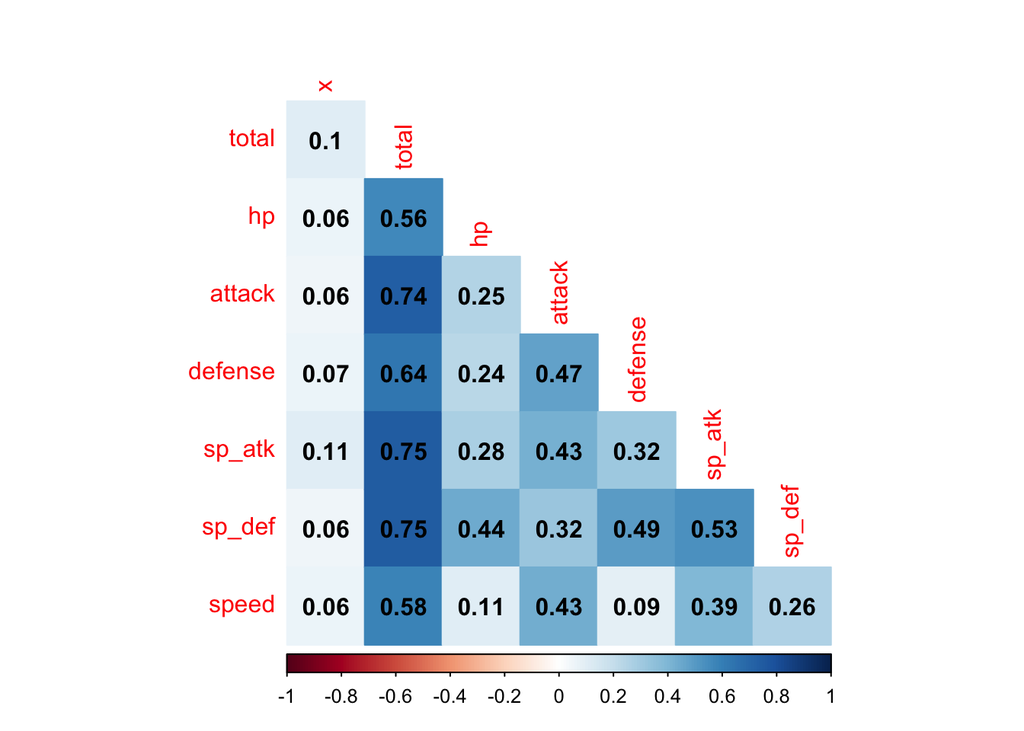

```r
pokemon_train2<-pokemon_train[,sapply(pokemon_train,is.numeric)]
pokemon_train2 %>%
  cor() %>%
  corrplot(type = 'lower', diag = FALSE,
           method = 'color',addCoef.col = 'Black')
```

What relationships, if any, do you notice? Do these relationships make sense to you?

3. First, set up a decision tree model and workflow. Tune the cost_complexity hyperparameter. Use the same levels we used in Lab 7 – that is, range = c(-3, -1). Specify that the metric we want to optimize is roc_auc.

Print an autoplot() of the results.

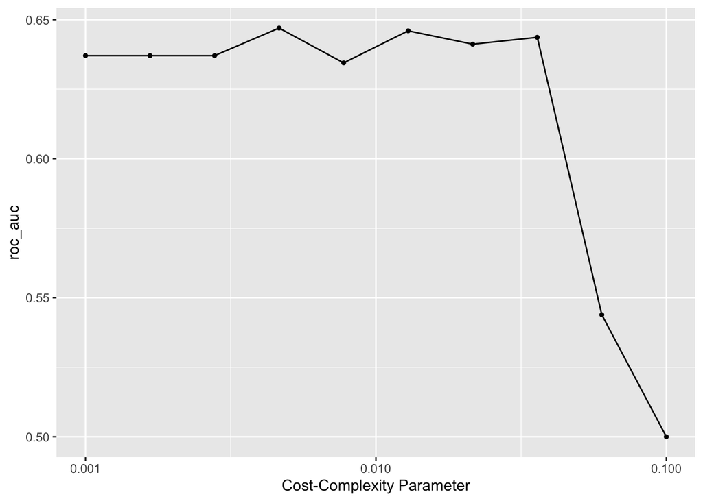

```r
tree_spec <- decision_tree() %>%
  set_engine("rpart")
class_tree_spec <- tree_spec %>%
  set_mode("classification")
class_tree_wf <- workflow() %>%
  add_model(class_tree_spec %>% set_args(cost_complexity = tune())) %>%
  add_recipe(pokemon_recipe)
param_grid <- grid_regular(cost_complexity(range = c(-3, -1)), levels = 10)

tune_res <- tune_grid(
  class_tree_wf,
  resamples = pokemon_fold,
  grid = param_grid,
  metrics = metric_set(roc_auc)
)
autoplot(tune_res)
```

What do you observe? Does a single decision tree perform better with a smaller or larger complexity penalty?

4. What is the roc_auc of your best-performing pruned decision tree on the folds? Hint: Use collect_metrics() and arrange().

```r
collect_metrics(tune_res)%>%
  arrange(-mean)
```

```
## # A tibble: 10 × 7
##    cost_complexity .metric .estimator  mean     n std_err .config
##              <dbl> <chr>   <chr>      <dbl> <int>   <dbl> <chr>
##  1         0.00464 roc_auc hand_till  0.647     5  0.0231 Preprocessor1_Model04
##  2         0.0129  roc_auc hand_till  0.646     5  0.0236 Preprocessor1_Model06
##  3         0.0359  roc_auc hand_till  0.644     5  0.0283 Preprocessor1_Model08
##  4         0.0215  roc_auc hand_till  0.641     5  0.0241 Preprocessor1_Model07
##  5         0.001   roc_auc hand_till  0.637     5  0.0207 Preprocessor1_Model01
##  6         0.00167 roc_auc hand_till  0.637     5  0.0207 Preprocessor1_Model02
##  7         0.00278 roc_auc hand_till  0.637     5  0.0207 Preprocessor1_Model03
##  8         0.00774 roc_auc hand_till  0.634     5  0.0231 Preprocessor1_Model05
##  9         0.0599  roc_auc hand_till  0.544     5  0.0272 Preprocessor1_Model09
## 10         0.1     roc_auc hand_till  0.5       5  0      Preprocessor1_Model10
```

The roc_auc is best performining at 0.64.

5. Using rpart.plot, fit and visualize your best-performing pruned decision tree with the training set.

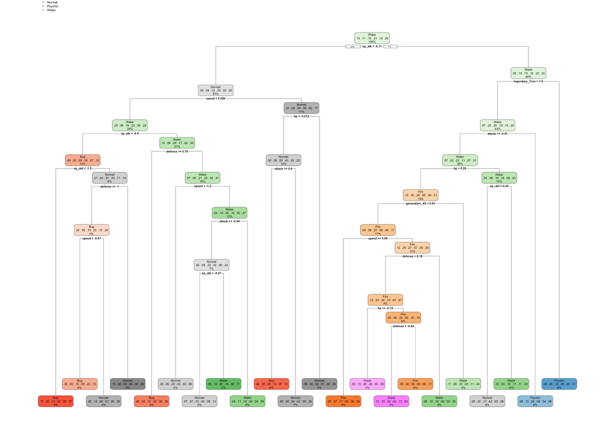

```r
best_complexity <- select_best(tune_res)
class_tree_final <- finalize_workflow(class_tree_wf, best_complexity)
class_tree_final_fit <- fit(class_tree_final, data = pokemon_train)
class_tree_final_fit %>%
  extract_fit_engine() %>%
  rpart.plot()
```

Now set up a random forest model and workflow. Use the ranger engine and set importance = “impurity”. Tune mtry, trees, and min_n. Using the documentation for rand_forest(), explain in your own words what each of these hyperparameters represent.

```r
rf_spec <- rand_forest() %>%
  set_engine("ranger", importance = "impurity") %>%
  set_mode("classification")
rf_wf <- workflow() %>%
  add_model(rf_spec %>% set_args(mtry = tune(), trees = tune(), min_n = tune())) %>%
  add_recipe(pokemon_recipe)
```

mtry: represents the number of predictors that are sampled in the split trees: the total trees min_n: minimum number of observations before splitting the nodes

Create a regular grid with 8 levels each. You can choose plausible ranges for each hyperparameter. Note that mtry should not be smaller than 1 or larger than 8. Explain why not. What type of model would mtry = 8 represent?

```r
param_grid2 <- grid_regular(mtry(range = c(1, 8)),trees(range = c(50,300)),min_n(range=c(1,5)), levels = 8)
```

mtry should not be smaller than 1 or larger than 8 because then it would become a bagging model. mtry=8 would make it a bagging model.

6. Specify roc_auc as a metric. Tune the model and print an autoplot() of the results.

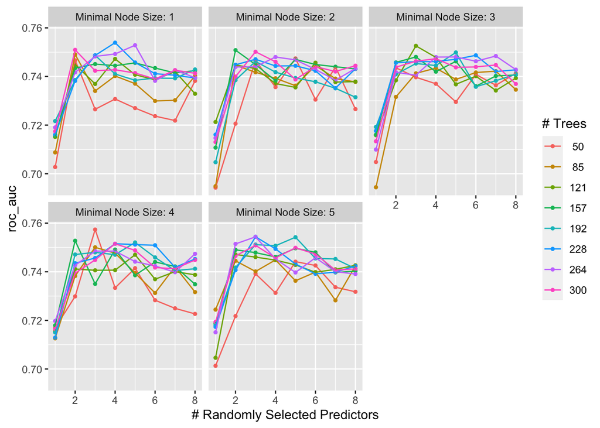

```r
tune_res2 <- tune_grid(
  rf_wf,
  resamples = pokemon_fold,
  grid = param_grid2,
  metrics = metric_set(roc_auc)
)

autoplot(tune_res2)
```

What do you observe? What values of the hyperparameters seem to yield the best performance?

7. What is the roc_auc of your best-performing random forest model on the folds? Hint: Use collect_metrics() and arrange().

```r
 collect_metrics(tune_res2)%>%
  arrange(-mean)
```

```
## # A tibble: 320 × 9
##     mtry trees min_n .metric .estimator  mean     n std_err .config
##    <int> <int> <int> <chr>   <chr>      <dbl> <int>   <dbl> <chr>
##  1     3    50     4 roc_auc hand_till  0.757     5 0.00793 Preprocessor1_Model…
##  2     3   228     5 roc_auc hand_till  0.754     5 0.0111  Preprocessor1_Model…
##  3     3   264     5 roc_auc hand_till  0.754     5 0.0116  Preprocessor1_Model…
##  4     5   192     5 roc_auc hand_till  0.754     5 0.00972 Preprocessor1_Model…
##  5     4   228     1 roc_auc hand_till  0.754     5 0.00940 Preprocessor1_Model…
##  6     5   264     1 roc_auc hand_till  0.753     5 0.00906 Preprocessor1_Model…
##  7     2   157     4 roc_auc hand_till  0.753     5 0.0125  Preprocessor1_Model…
##  8     3   121     3 roc_auc hand_till  0.753     5 0.0112  Preprocessor1_Model…
##  9     5   192     4 roc_auc hand_till  0.752     5 0.00793 Preprocessor1_Model…
## 10     4   300     4 roc_auc hand_till  0.752     5 0.0107  Preprocessor1_Model…
## # … with 310 more rows
```

The roc_auc is 0.757.

8. Create a variable importance plot, using vip(), with your best-performing random forest model fit on the training set.

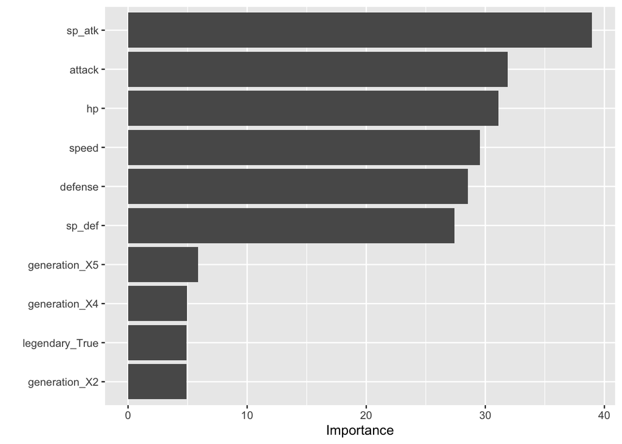

```r
best_complexity2 <- select_best(tune_res2)
rf_final <- finalize_workflow(rf_wf, best_complexity2)
rf_final_fit <- fit(rf_final, data = pokemon_train)
rf_final_fit %>%
  extract_fit_engine() %>%
  vip()
```

Which variables were most useful? Which were least useful? Are these results what you expected, or not?

sp_atk, attack, speed, hp, sp_def, and defense seem to be the most useful. generation_X5, legendary_True, generation_X4, and generation_X2 seem the least useful. I would say these results are expected.

9. Finally, set up a boosted tree model and workflow. Use the xgboost engine. Tune trees. Create a regular grid with 10 levels; let trees range from 10 to 2000. Specify roc_auc and again print an autoplot() of the results.

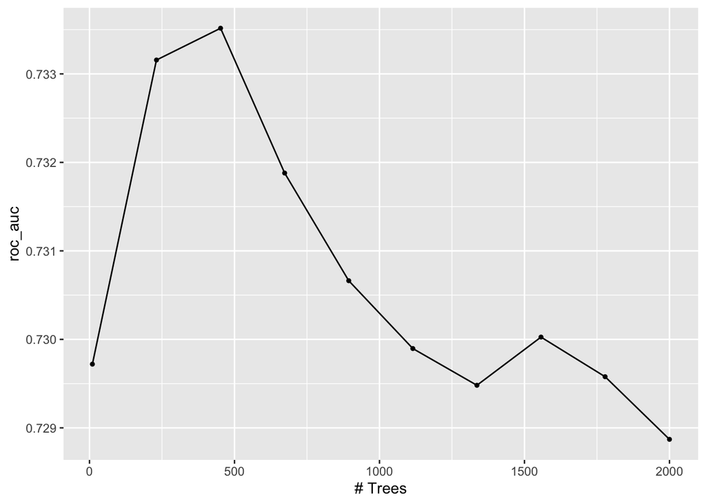

```r
bt_spec <- boost_tree() %>%
  set_engine("xgboost") %>%
  set_mode("classification")
bt_wf <- workflow() %>%
  add_model(bt_spec %>% set_args(trees = tune())) %>%
  add_recipe(pokemon_recipe)
param_grid3 <- grid_regular(trees(range = c(10,2000)), levels = 10)
tune_res3 <- tune_grid(
  bt_wf,
  resamples = pokemon_fold,
  grid = param_grid3,
  metrics = metric_set(roc_auc)
)
autoplot(tune_res3)
```

What do you observe?

What is the roc_auc of your best-performing boosted tree model on the folds? Hint: Use collect_metrics() and arrange().

```r
collect_metrics(tune_res3)%>%
  arrange(-mean)
```

```
## # A tibble: 10 × 7
##    trees .metric .estimator  mean     n std_err .config
##    <int> <chr>   <chr>      <dbl> <int>   <dbl> <chr>
##  1   452 roc_auc hand_till  0.734     5  0.0108 Preprocessor1_Model03
##  2   231 roc_auc hand_till  0.733     5  0.0117 Preprocessor1_Model02
##  3   673 roc_auc hand_till  0.732     5  0.0108 Preprocessor1_Model04
##  4   894 roc_auc hand_till  0.731     5  0.0104 Preprocessor1_Model05
##  5  1557 roc_auc hand_till  0.730     5  0.0115 Preprocessor1_Model08
##  6  1115 roc_auc hand_till  0.730     5  0.0104 Preprocessor1_Model06
##  7    10 roc_auc hand_till  0.730     5  0.0114 Preprocessor1_Model01
##  8  1778 roc_auc hand_till  0.730     5  0.0111 Preprocessor1_Model09
##  9  1336 roc_auc hand_till  0.729     5  0.0113 Preprocessor1_Model07
## 10  2000 roc_auc hand_till  0.729     5  0.0107 Preprocessor1_Model10
```

The roc_auc of the best performing boosted tree model is 0.733.

10. Display a table of the three ROC AUC values for your best-performing pruned tree, random forest, and boosted tree models. Which performed best on the folds? Select the best of the three and use select_best(), finalize_workflow(), and fit() to fit it to the testing set.

```r
a<-collect_metrics(tune_res)%>%
  arrange(-mean)%>%
  filter(row_number()==1)
a['type']<-'pt'
b<-collect_metrics(tune_res2)%>%
  arrange(-mean)%>%
  filter(row_number()==1)
b['type']<-'rf'
c<-collect_metrics(tune_res3)%>%
  arrange(-mean)%>%
  filter(row_number()==1)
c['type']<-'bt'
inner1<-rbind(a[2:8],b[4:10])
inner2<-rbind(inner1,c[2:8])
inner2
```

```
## # A tibble: 3 × 7
##   .metric .estimator  mean     n std_err .config                type
##   <chr>   <chr>      <dbl> <int>   <dbl> <chr>                  <chr>
## 1 roc_auc hand_till  0.647     5 0.0231  Preprocessor1_Model04  pt
## 2 roc_auc hand_till  0.757     5 0.00793 Preprocessor1_Model195 rf
## 3 roc_auc hand_till  0.734     5 0.0108  Preprocessor1_Model03  bt
```

Random forest works best.

Print the AUC value of your best-performing model on the testing set. Print the ROC curves. Finally, create and visualize a confusion matrix heat map.

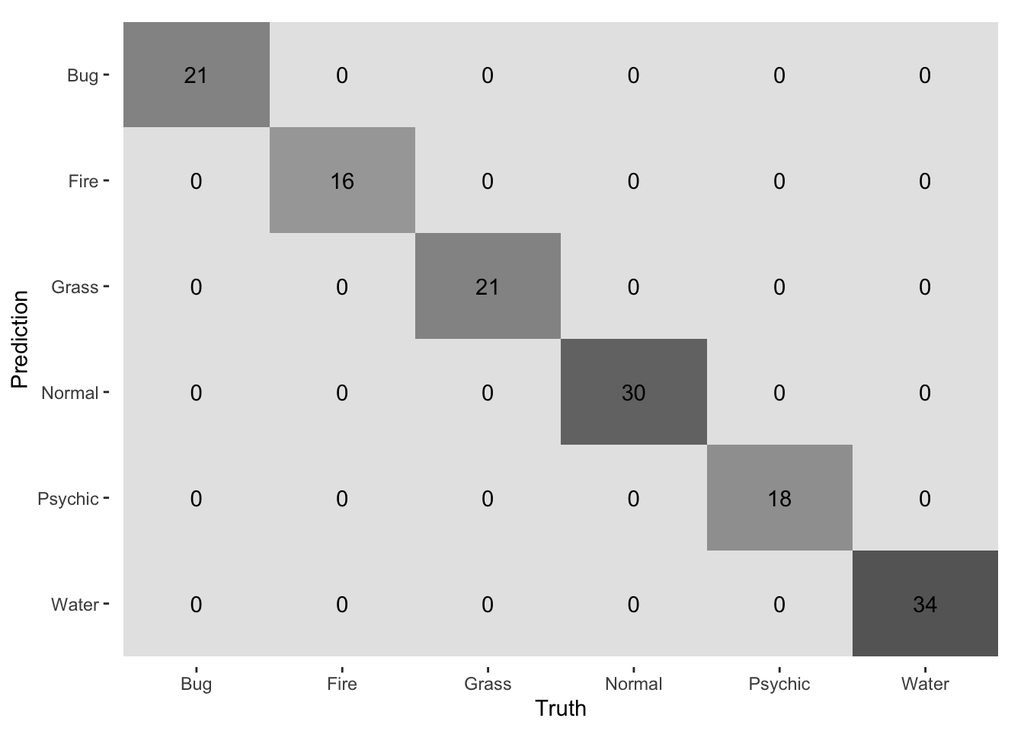

```r
best_complexity2 <- select_best(tune_res2)
rf_final2 <- finalize_workflow(rf_wf, best_complexity2)
rf_final_fit2 <- fit(rf_final, data = pokemon_test)
augment(rf_final_fit2, new_data = pokemon_test) %>%
  conf_mat(truth = type_1, estimate = .pred_class) %>%
  autoplot(type = "heatmap")
```

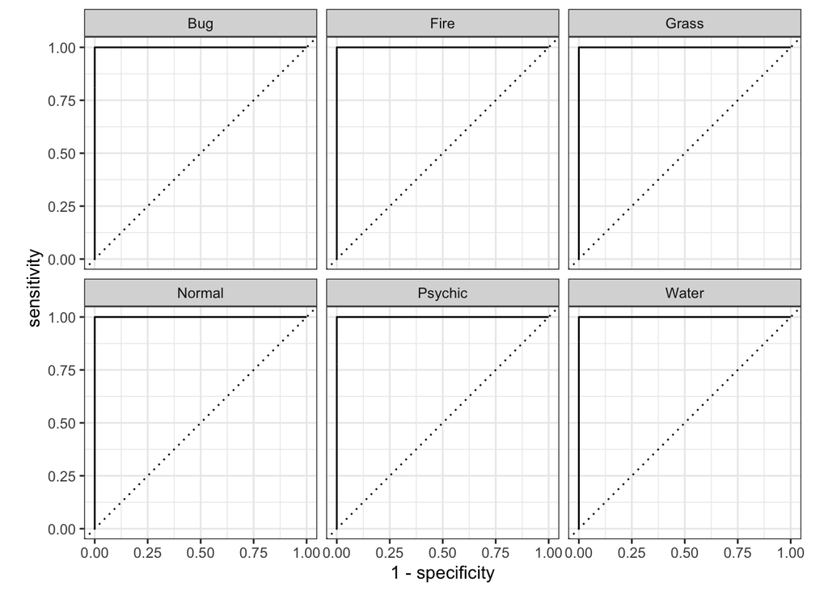

```r
 augment(rf_final_fit2, new_data = pokemon_test) %>%
  roc_curve(type_1,.pred_Bug,.pred_Fire,.pred_Grass,.pred_Normal,
            .pred_Psychic,.pred_Water) %>%
  autoplot()
```

```r
 augment(rf_final_fit2, new_data = pokemon_test) %>%
  roc_auc(type_1,.pred_Bug,.pred_Fire,.pred_Grass,.pred_Normal,.pred_Psychic,.pred_Water)
```

```
## # A tibble: 1 × 3
##   .metric .estimator .estimate
##   <chr>   <chr>          <dbl>
## 1 roc_auc hand_till          1
```

Which classes was your model most accurate at predicting? Which was it worst at?

They were all fit to the testing set so they are all accurate.